# datos

## Análisis de datos de viajes de bicicletas en CABA

### por Nazareno Amidolare

Dataset: https://data.buenosaires.gob.ar/dataset/bicicletas-publicas

### 1. Carga y preprocesamiento de datos

```python
import pandas as pd
import numpy as np
import matplotlib.pyplot as plt
import folium
from folium.plugins import HeatMap

# Cargo los datos
df = pd.read_csv("trips_2023.csv")

print(df.head())
print(df.dtypes)
```

```
   Unnamed: 0       Id_recorrido duracion_recorrido fecha_origen_recorrido  \
0           1  17910696BAEcobici              1,848    2023-04-24 10:30:10
1           2  17600256BAEcobici                288    2023-03-22 17:40:55
2           3  17255670BAEcobici              1,103    2023-02-15 23:12:22
3           4  17996972BAEcobici              1,165    2023-05-03 11:00:20
4           5  17148836BAEcobici                378    2023-02-06 06:50:58

  id_estacion_origen        nombre_estacion_origen  \
0       358BAEcobici                  249 - Balbín
1       444BAEcobici  061 - Ministerio de Economia
2       280BAEcobici           222 - SIMON BOLIVAR
3       273BAEcobici                  223 - GAINZA
4        65BAEcobici          065 - Julián Álvarez

           direccion_estacion_origen  long_estacion_origen  \
0                        2519 Conesa            -58.465586
1  Balcarce e Yrigoyen, Hipolito Av.            -58.370716
2   1701 Fernandez Moreno, Baldomero            -58.449379
3       494 Gainza, Martin De, Gral.            -58.446751
4                        3822 Guemes            -58.415787

   lat_estacion_origen fecha_destino_recorrido id_estacion_destino  \
0           -34.561486     2023-04-24 11:00:58        278BAEcobici
1           -34.608936     2023-03-22 17:45:43          3BAEcobici
2           -34.633528     2023-02-15 23:30:45        280BAEcobici
3           -34.616758     2023-05-03 11:19:45        367BAEcobici
4           -34.587312     2023-02-06 06:57:16         14BAEcobici

  nombre_estacion_destino         direccion_estacion_destino  \
0            233 - MONROE                        2519 Superi
1            003 - ADUANA                  Moreno & Azopardo
2     222 - SIMON BOLIVAR   1701 Fernandez Moreno, Baldomero
3       287 - Belaustegui        Belaustegui, Luis, Dr. 2890
4          014 - Pacifico  Santa Fe Av. & Bullrich, Int. Av.

   long_estacion_destino  lat_estacion_destino       id_usuario  \
0             -58.469813            -34.564122  861866BAEcobici
1             -58.368174            -34.611102  217525BAEcobici
2             -58.449379            -34.633528  954201BAEcobici
3             -58.477209            -34.616212  179414BAEcobici
```

[output cut: 12 more lines]

```
id_estacion_origen             object
nombre_estacion_origen         object
direccion_estacion_origen      object
long_estacion_origen          float64
lat_estacion_origen           float64
fecha_destino_recorrido        object
id_estacion_destino            object
nombre_estacion_destino        object
direccion_estacion_destino     object
long_estacion_destino         float64
lat_estacion_destino          float64
id_usuario                     object
modelo_bicicleta               object
género                         object
dtype: object
```

Veo q debería corregir los datatypes

```python
for s in ["origen", "destino"]:
    # ESTACIÓN
    df["id_estacion_" + s] = df["id_estacion_" + s].str.replace("BAEcobici", "")
    df["nombre_estacion_" + s] = df["nombre_estacion_" + s]  # los primeros 6 chars son "NNN - "
    # direccion_estacion
    df["long_estacion_" + s] = pd.to_numeric(df["long_estacion_" + s])
    df["lat_estacion_" + s] = pd.to_numeric(df["lat_estacion_" + s])

# RECORRIDO
df["Id_recorrido"] = pd.to_numeric(df["Id_recorrido"].astype(str).str.replace("BAEcobici", ""))
df["fecha_origen_recorrido"] = pd.to_datetime(df["fecha_origen_recorrido"])
df["fecha_destino_recorrido"] = pd.to_datetime(df["fecha_destino_recorrido"])
df["duracion_recorrido"] = pd.to_numeric(df["duracion_recorrido"].astype(str).str.replace(",", ""))

print(df.head())
print(df.dtypes)
```

```
   Unnamed: 0  Id_recorrido  duracion_recorrido fecha_origen_recorrido  \
0           1      17910696                1848    2023-04-24 10:30:10
1           2      17600256                 288    2023-03-22 17:40:55
2           3      17255670                1103    2023-02-15 23:12:22
3           4      17996972                1165    2023-05-03 11:00:20
4           5      17148836                 378    2023-02-06 06:50:58

  id_estacion_origen        nombre_estacion_origen  \
0                358                  249 - Balbín
1                444  061 - Ministerio de Economia
2                280           222 - SIMON BOLIVAR
3                273                  223 - GAINZA
4                 65          065 - Julián Álvarez

           direccion_estacion_origen  long_estacion_origen  \
0                        2519 Conesa            -58.465586
1  Balcarce e Yrigoyen, Hipolito Av.            -58.370716
2   1701 Fernandez Moreno, Baldomero            -58.449379
3       494 Gainza, Martin De, Gral.            -58.446751
4                        3822 Guemes            -58.415787

   lat_estacion_origen fecha_destino_recorrido id_estacion_destino  \
0           -34.561486     2023-04-24 11:00:58                 278
1           -34.608936     2023-03-22 17:45:43                   3
2           -34.633528     2023-02-15 23:30:45                 280
3           -34.616758     2023-05-03 11:19:45                 367
4           -34.587312     2023-02-06 06:57:16                  14

  nombre_estacion_destino         direccion_estacion_destino  \
0            233 - MONROE                        2519 Superi
1            003 - ADUANA                  Moreno & Azopardo
2     222 - SIMON BOLIVAR   1701 Fernandez Moreno, Baldomero
3       287 - Belaustegui        Belaustegui, Luis, Dr. 2890
4          014 - Pacifico  Santa Fe Av. & Bullrich, Int. Av.

   long_estacion_destino  lat_estacion_destino       id_usuario  \
0             -58.469813            -34.564122  861866BAEcobici
1             -58.368174            -34.611102  217525BAEcobici
2             -58.449379            -34.633528  954201BAEcobici
3             -58.477209            -34.616212  179414BAEcobici
```

[output cut: 12 more lines]

```
id_estacion_origen                    object
nombre_estacion_origen                object
direccion_estacion_origen             object
long_estacion_origen                 float64
lat_estacion_origen                  float64
fecha_destino_recorrido       datetime64[ns]
id_estacion_destino                   object
nombre_estacion_destino               object
direccion_estacion_destino            object
long_estacion_destino                float64
lat_estacion_destino                 float64
id_usuario                            object
modelo_bicicleta                      object
género                                object
dtype: object
```

### 2. Análisis exploratorio

1. Duración de los viajes

```python
df["duracion_recorrido_min"] = df["duracion_recorrido"] / 60
# Descripción de los datos
df["duracion_recorrido_min"].describe()
```

```
count    1.937385e+06
mean     2.313341e+01
std      2.270847e+02
min      1.016667e+00
25%      9.550000e+00
50%      1.551667e+01
75%      2.503333e+01
max      1.034710e+05
Name: duracion_recorrido_min, dtype: float64
```

- La duración media de los viajes es de 23 minutos.
- El 75% de los viajes duran menos de 25 minutos.

La empresa podría realizar experimentos con nuevos modelos de bicicleta o estaciones, y usar la media para evaluar si la duración de los viajes aumenta o disminuye.

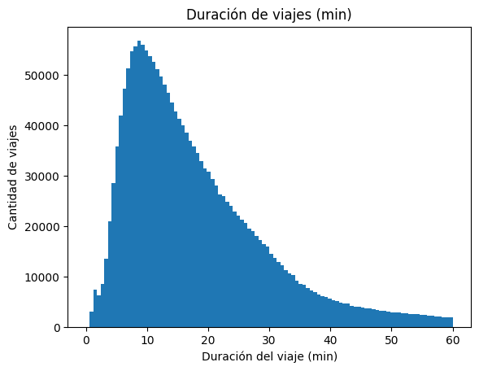

```python
# Histograma de duración de viajes
plt.hist(df["duracion_recorrido_min"], bins=100, range=(0, 60)) # hasta 1hr para evitar outliers
plt.xlabel("Duración del viaje (min)")
plt.ylabel("Cantidad de viajes")
plt.title("Duración de viajes (min)")
plt.show()
```

```python
df["duracion_recorrido_min"].mode()
```

```
0    8.9
Name: duracion_recorrido_min, dtype: float64
```

```python
df["fecha_origen_recorrido_hora"] = df["fecha_origen_recorrido"].dt.hour
df["fecha_origen_recorrido_hora"].describe()
```

```
count    1.937385e+06
mean     1.422504e+01
std      5.249164e+00
min      0.000000e+00
25%      1.100000e+01
50%      1.500000e+01
75%      1.800000e+01
max      2.300000e+01
Name: fecha_origen_recorrido_hora, dtype: float64
```

- La mayoría de los usuarios comienza su recorrido entre las 9 y 19 hs (esto basado en media 14 y desviación estándar 5)

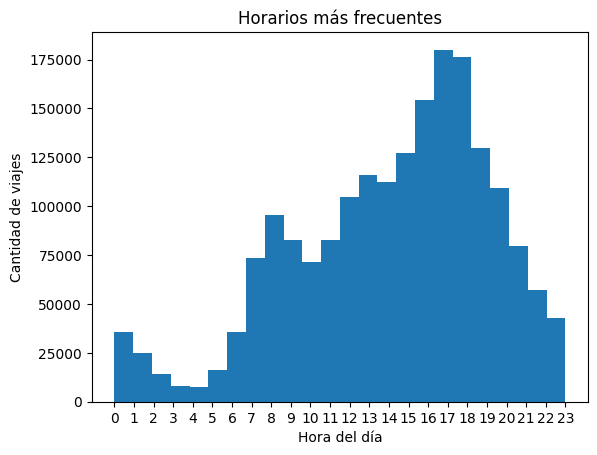

```python
# Histograma de horario de viajes
plt.hist(df["fecha_origen_recorrido_hora"], bins=24)
plt.xlabel("Hora del día")
plt.ylabel("Cantidad de viajes")
plt.title("Horarios más frecuentes")
plt.xticks(range(0, 24))
plt.show()
```

```python
N = 1000
df_top = df.groupby(["id_estacion_origen", "nombre_estacion_origen", "lat_estacion_origen", "long_estacion_origen", "id_estacion_destino", "nombre_estacion_destino", "lat_estacion_destino", "long_estacion_destino"]).size().reset_index(name="count").sort_values(by="count", ascending=False).head(N)

mapa = folium.Map(location=[-34.603722, -58.381592], zoom_start=12)

for i in range(len(df_top)):
    folium.CircleMarker(
        location=[df_top["lat_estacion_origen"].iloc[i], df_top["long_estacion_origen"].iloc[i]],
        radius=1,
        color="blue",
        fill=True,
        fill_color="blue",
    ).add_to(mapa)

    folium.CircleMarker(
        location=[df_top["lat_estacion_destino"].iloc[i], df_top["long_estacion_destino"].iloc[i]],
        radius=1,
        color="red",
        fill=True,
        fill_color="red",
    ).add_to(mapa)

heat_data_origin = [[ row["lat_estacion_origen"], row["long_estacion_origen"]] for _, row in df_top.iterrows()]
HeatMap(heat_data_origin, radius=12, blur=6).add_to(mapa)

heat_data_destination = [[ row["lat_estacion_destino"], row["long_estacion_destino"]] for _, row in df_top.iterrows()]
HeatMap(heat_data_destination, radius=12, blur=6).add_to(mapa)

mapa
```

Make this Notebook Trusted to load map: File -> Trust Notebook

[interactive chart not shown]

- Observando las estaciones más concurridas podemos entender mejor donde optimizar el servicio, por ejemplo, agregando más bicicletas o estaciones.

### 4. Más análisis temporal: uso según día de la semana y mes

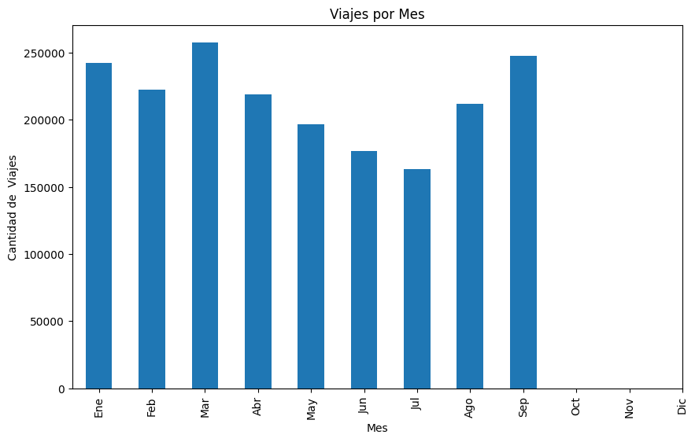

```python
# Viajes por mes
plt.figure(figsize=(10, 6))
df["fecha_origen_recorrido"].dt.month.value_counts().sort_index().plot(kind="bar")
plt.xticks(np.arange(12), ["Ene", "Feb", "Mar", "Abr", "May", "Jun", "Jul", "Ago", "Sep", "Oct", "Nov", "Dic"])
plt.xlabel("Mes")
plt.ylabel("Cantidad de  Viajes")
plt.title("Viajes por Mes")
plt.show()
```

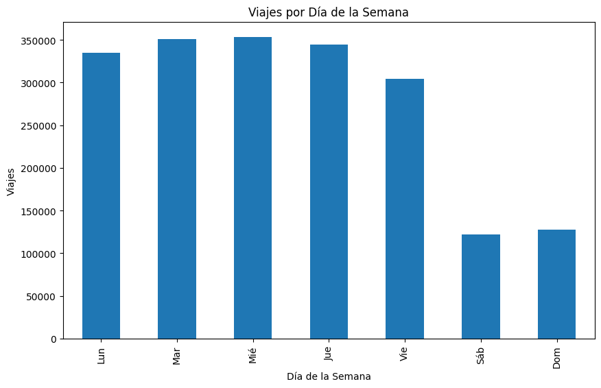

```python
# Viajes por día de la semana
plt.figure(figsize=(10, 6))
df["fecha_origen_recorrido"].dt.dayofweek.value_counts().sort_index().plot(kind="bar")
plt.xticks(np.arange(7), ["Lun", "Mar", "Mié", "Jue", "Vie", "Sáb", "Dom"])
plt.xlabel("Día de la Semana")
plt.ylabel("Viajes")
plt.title("Viajes por Día de la Semana")
plt.show()
```

- Vemos q los viajes aumentan en los días de semana, y disminuyen los fines de semana, esto es esperable porq la gente usa las bicicletas para ir a trabajar o estudiar.

### 6. Uso según género

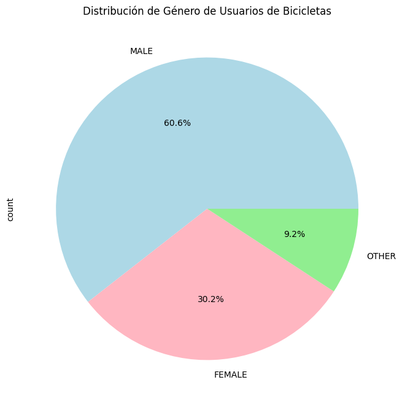

```python
plt.figure(figsize=(8, 8))
df["género"].value_counts().plot(kind="pie", autopct='%1.1f%%', colors=["lightblue", "lightpink", "lightgreen"])
plt.title("Distribución de Género de Usuarios de Bicicletas")
plt.show()
```

- Vemos q los hombres usan más las bicicletas q las mujeres.

Modelo de bici más usado

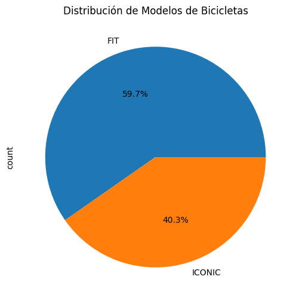

```python
plt.figure(figsize=(8, 6))
df["modelo_bicicleta"].value_counts().plot(kind="pie", autopct='%1.1f%%')
plt.title("Distribución de Modelos de Bicicletas")
plt.show()
```